# Random Assignment and Experiments

Steven V. Miller, svmiller.com

4 February 2021

Abstract

This is a lab script for [POST 8000](http://post8000.svmiller.com), a graduate-level quantitative methods for public policy class that I teach at Clemson University. It will not be the most sophisticated R-related write-up of mine—check [my blog](http://svmiller.com/blog) for those—but it should be useful for discussion around the associated R script for the week’s ‘lab’ session.

# R Packages/Data for This Session

The data we’ll be using were cobbled from the [data made available](https://www.masteringmetrics.com/resources/) by the authors of *Mastering ’Metrics*. I also want to note that Jeff Arnold, helpfully, ganked these data and did a lot of pre-processing of them, which I mirrored on my end before making these data available in my `{stevedata}` package. I did want to issue one caveat about these data, more a complaint about Mastering ’Metrics. That is: these data are not as well-sourced as I’d like. There’s a bit of a leap of faith in terms of the data made available and what the authors provide in their textbook. The results are effectively able to be replicated, but not perfectly.

Anywho, here are the data and packages we’ll be using.

```r
library(tidyverse)
library(stevedata)
```

# The Idea of Random Assignment

The idea of random assignment is that it is ideal for the sake of causal inference that a “treatment” of interest is randomly assigned within a controlled setting. For entry students, this sounds strange—shouldn’t treatments be allocated on basis of need or something to that effect? The answer from a causal inference perspective is “no, of course not.” Strange as this may seem to a lay person, but the logic is that you want people receiving the treatment to be equal in expectation to those who do not receive the treatment. There may be random differences between the group that receives the treatment and the (control) group that does not *but you want the only systematic difference between the two groups to be the treatment itself*.

Let’s think of a simple/hypothetical case here. Assume we recruited 685 people for an experiment. There is no special reason for the number 685; it just happened to come off my fingertips. The subjects in this pool of 685 people either received the treatment (1) or did not receive the treatment (0). Thereafter, we took some measurements from the pool on some outcome of interest (`y`). On average, the true effect of the treatment on the outcome of interest is that a unit change in the treatment (i.e. receiving it) increases the value of `y` by 1, even if the errors randomly distributed around those effects are some what diffuse. The data would look something like this.

```r
set.seed(8675309) # Jenny, I got your number

tibble(id = seq(1:685),
       treat = sample(c(0, 1), 685, replace=TRUE),
       y = 50 + treat + rnorm(685, 0, 2.5)) -> D
```

It looks like we isolated the treatment effect pretty well. That’s the benefit of dealing with larger samples. If you want to give this a whirl for yourself, try reducing the number of observations to something like 100.

```r
broom::tidy(t.test(y ~ treat, data = D))
```

```
## # A tibble: 1 x 10
##   estimate estimate1 estimate2 statistic p.value parameter conf.low conf.high
##      <dbl>     <dbl>     <dbl>     <dbl>   <dbl>     <dbl>    <dbl>     <dbl>
## 1   -0.944      49.9      50.8     -4.99 7.69e-7      655.    -1.31    -0.572
## # … with 2 more variables: method <chr>, alternative <chr>
```

Because the number of observations is odd, there’s going to be a slight discrepancy between who receives the treatment and who does not. It’s immaterial here that treatment and control are not equal in size. Importantly, we basically did go-go-gadget randomization a la the `sample()` function in R.

```r
D %>% group_by(treat) %>% tally()
```

```
## # A tibble: 2 x 2
##   treat     n
## * <dbl> <int>
## 1     0   362
## 2     1   323
```

Now, let’s illustrate the logic of random sample, if with some kind of ex post R chicanery. Notice the treatment/control group sizes above? Let’s use that as the basis for assigning the sex of the respondent. The first 362 observations will be men. The next 323 observations will be women. Then, we’re going to use the `id` column (which is effectively just a unique identifier for the respondent) to create some more identifying information. We’ll make 10 roughly equal quantiles from the ID number that will serve as age bracket for 1) 18-29, 2) 30-39, 3) 40-49, 4) 50-59, and 5) 60-85. These ages will be drawn randomly from a uniform distribution with those appropriate minimums and maximums based on that information. The age stuff will lean on the `rowwise()` function.

Here’s a way of thinking about this hypothetical experiment. Assume we ran our shop from 8 a.m. to 5 p.m. or something like that. In our weird case, the first 362 people that showed up were dudes. The women didn’t start showing up until about halfway through the experiment. Further, the youngest people either showed up first thing in the morning or before the experiment closed shop. The older subjects only arrived midway through the day. In other words, there is clear variation between who arrives for the experiment *but the allocation of the treatment is still effectively random.*

```r
set.seed(8675309)
D %>%
  mutate(female = c(rep(0, 362), rep(1, 323)),
         quantile = ntile(id, 10)) %>%
  rowwise() %>%
  mutate(age = case_when(
    quantile %in% c(1, 10) ~ runif(1, 18, 29),
    quantile %in% c(2, 9) ~ runif(1, 30, 39),
    quantile %in% c(3, 8) ~ runif(1, 40, 49),
    quantile %in% c(4, 7) ~ runif(1, 50, 59),
    quantile %in% c(5, 6) ~ runif(1, 60, 85)
    )) %>% ungroup() %>%
  mutate(age = round(age)) -> D
```

While I can’t imagine many full-time experimentalists would advise running a controlled experiment where there are major correlates for who arrives at what time for the experiment, the idea is that the allocation of the treatment should still be randomly assigned. In other words, no matter the systematic determinants of subject arrival, the allocation of treatment and control is unaffected and, thus, the difference in group compositions should still be random. In our case, notice there is no systematic differences between treatment and control by age…

```r
broom::tidy(t.test(age ~ treat, data = D))
```

```
## # A tibble: 1 x 10
##   estimate estimate1 estimate2 statistic p.value parameter conf.low conf.high
##      <dbl>     <dbl>     <dbl>     <dbl>   <dbl>     <dbl>    <dbl>     <dbl>
## 1     1.90      46.5      44.6      1.46   0.146      678.   -0.662      4.47
## # … with 2 more variables: method <chr>, alternative <chr>
```

…or by gender. Here, I’ll note how much I hate how clunky the `prop.test()` is in R and how little I do these in my day-to-day stuff to be aware of fancier alternatives.

```r
D %>%
  group_by(female, treat) %>%
  tally() %>% group_by(treat) %>%
  mutate(treat_tot = sum(n)) %>%
  arrange(treat_tot)
```

```
## # A tibble: 4 x 4
## # Groups:   treat [2]
##   female treat     n treat_tot
##    <dbl> <dbl> <int>     <int>
## 1      0     1   178       323
## 2      1     1   145       323
## 3      0     0   184       362
## 4      1     0   178       362
```

```r
# test for proportion of women by different treatment groups.
broom::tidy(prop.test(x = c(145, 178), n = c(323, 362)))
```

```
## # A tibble: 1 x 9
##   estimate1 estimate2 statistic p.value parameter conf.low conf.high method
##       <dbl>     <dbl>     <dbl>   <dbl>     <dbl>    <dbl>     <dbl> <chr>
## 1     0.449     0.492      1.09   0.297         1   -0.121    0.0349 2-sam…
## # … with 1 more variable: alternative <chr>
```

There are differences between treatment and control, but they are random differences. The only systematic difference that emerges is the treatment.

With that in mind, let’s dig into the data made available from the authors of *Mastering ’Metrics* to replicate some of what they discuss.

# The 2009 National Health Insurance Survey (NHIS)

We’ll start with the the 2009 NHIS example from Chapter 1. I have this in `{stevedata}` as `mm_nhis`.

```r
?mm_nhis
mm_nhis
```

```
## # A tibble: 18,790 x 10
##      fml    hi  hlth nwhite   age  yedu famsize  empl     inc perweight
##    <dbl> <dbl> <dbl>  <dbl> <dbl> <dbl>   <dbl> <dbl>   <dbl>     <dbl>
##  1     1     0     4      0    29    14       4     0  19283.      8938
##  2     0     0     4      0    35    11       4     1  19283.      8967
##  3     0     1     3      0    32    12       4     1 167845.      8905
##  4     1     1     3      0    34    16       4     1 167845.      8889
##  5     0     1     4      0    45    12       2     1  85986.      9587
##  6     1     1     4      0    44    12       2     1  85986.      9080
##  7     0     1     4      0    49    16       3     1 167845.     10226
##  8     1     1     1      0    55    11       3     0 167845.      9452
##  9     0     1     4      0    46    12       2     1  61103.      4031
## 10     1     1     4      0    43    12       2     1  61103.      2725
## # … with 18,780 more rows
```

Let’s go explore these data some. First, let’s start with the health index, which is a numeric vector for a health index, broadly understood, that ranges from 1-5. I have some misgivings about communicating this via means. I’ll belabor that reservation more in a few weeks. However, let’s go look at the health index as a function of having health insurance (yes or no, 1 or 0) by both men and women.

```r
mm_nhis %>%
  group_by(fml, hi) %>%
  summarize(mean_hlth = mean(hlth),
            sd_hlth = sd(hlth)) %>%
  group_by(fml) %>%
  mutate(diff = mean_hlth - lag(mean_hlth))
```

```
## # A tibble: 4 x 5
## # Groups:   fml [2]
##     fml    hi mean_hlth sd_hlth   diff
##   <dbl> <dbl>     <dbl>   <dbl>  <dbl>
## 1     0     0      3.70   1.01  NA
## 2     0     1      3.98   0.934  0.278
## 3     1     0      3.61   1.02  NA
## 4     1     1      3.99   0.928  0.382
```

Minus some rounding, or perhaps some weighting, we basically reproduced the means from the top row of Table 1.1. The difference in means for having health insurance is about .278 for men and about .382 for women.

Notice that the presence of a standard error in parentheses around the difference in Table 1.1 implies they’re communicating the difference in means via *t*-test. You can also do that even as it takes some acclimation with the *t*-test. Basically, the default output in the `t.test()` function in base R is from a Welch’s two-sample test (i.e. the groups/treatments have unequal variances) and the test is two-tailed.

```r
mm_nhis %>%
  group_by(fml) %>%
  do(broom::tidy(t.test(hlth ~ hi, data = .))) %>%
  data.frame
```

```
##   fml   estimate estimate1 estimate2 statistic      p.value parameter
## 1   0 -0.2777127  3.699150  3.976862  -9.95330 7.889567e-23  2067.016
## 2   1 -0.3823869  3.609689  3.992075 -13.27285 1.623150e-38  1902.160
##     conf.low  conf.high                  method alternative
## 1 -0.3324308 -0.2229946 Welch Two Sample t-test   two.sided
## 2 -0.4388888 -0.3258850 Welch Two Sample t-test   two.sided
```

Of note: the authors of *Mastering ’Metrics* report the standard error of the difference whereas the default output in a tidied *t*-test is the 95% confidence interval. If it were that important for you to extract the standard error in a simple application like this, I think you’d have to do it manually independent of the `tidy()` function. For example, here’s what it’d be for men.

```r
t_men <- t.test(hlth ~ hi, data = subset(mm_nhis, fml == 0))
as.vector(abs(diff(t_men$estimate)/t_men$statistic))
```

```
## [1] 0.02790157
```

And here’s what it’d be for women:

```r
t_women <- t.test(hlth ~ hi, data = subset(mm_nhis, fml == 1))
as.vector(abs(diff(t_women$estimate)/t_women$statistic))
```

```
## [1] 0.0288097
```

Knowing what you know about confidence intervals, standard errors, and the normal distribution, you could manually calculate the confidence interval. It’ll tell you the same thing: for men and women, those having at least some health insurance score higher in their health index than those that don’t.

I don’t know where you all are re: getting comfortable with *t*-test output, but a graphical rendering of what the *t*-test is effectively telling you may help. Here, for both men and women, the 95% intervals around general health estimates for those with and without health insurance do not overlap.

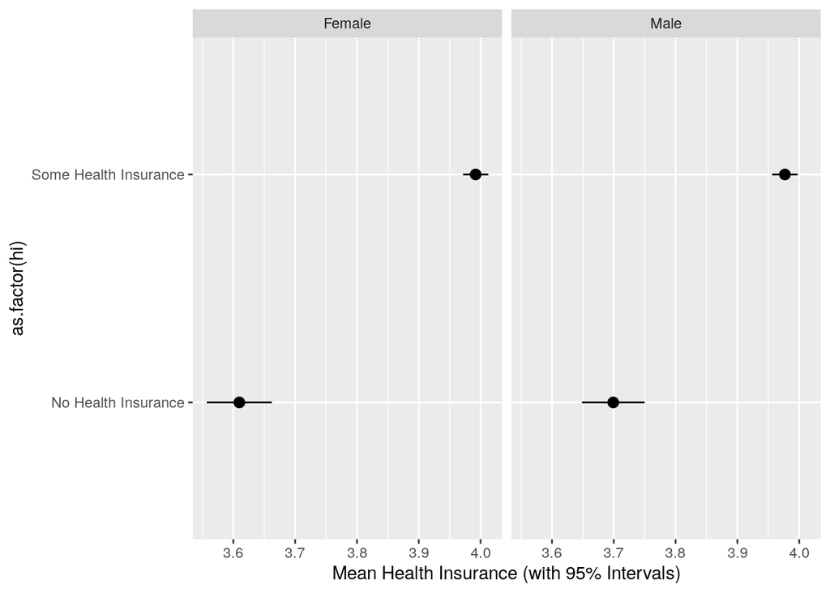

```r
mm_nhis %>%
  mutate(female = ifelse(fml == 0, "Male", "Female")) %>%
  group_by(female, hi) %>%
  summarize(mean = mean(hlth, na.rm=T),
            sd = sd(hlth),
            lwr = mean - (abs(qnorm(.025))*(sd/sqrt(n()))),
            upr = mean + (abs(qnorm(.025))*(sd/sqrt(n())))) %>%
  group_by(female) %>%
  # Notice this will tell you basically what you learned above.
  mutate(diff = mean - lag(mean, 1)) %>%
  # You can visualize this too.
  ggplot(.,aes(as.factor(hi), mean, ymin=lwr, ymax=upr)) +
  facet_wrap(~female) +
  geom_pointrange() + coord_flip() +
  scale_x_discrete(labels = c("No Health Insurance", "Some Health Insurance")) +
  labs(y = "Mean Health Insurance (with 95% Intervals)")
```

Let’s [Leeroy Jenkins this](https://www.youtube.com/watch?v=mLyOj_QD4a4) now and fully reproduce Table 1.1 in *Mastering ’Metrics*. Here’s what we’re going to do. First, we’re going to select just we want and “gather” it with the `gather()` function that comes in the tidyverse (by way of `{tidyr}`). Then, we’re going to recode the health insurance variable for readability purposes. Thereafter, we’re going to group-split the data by dependent variable and gender. We’ll call this new object `Listie`, because I am bad at naming objects. Do as I say, not as I do on this front.

```r
mm_nhis %>%
  select(-perweight) %>%
  gather(var, val, -fml, -hi) %>%
  # This is a little convoluted, but it'll help readability for comparing to Table 1.1
  mutate(hi = ifelse(hi == 0, 1, 0)) %>%
  group_split(var, fml) -> Listie # note: I can be really bad with object names.
```

Inspecting the intermediate output, I see that there are 14 data frames in the list of data frames. The sequence goes, for each DV, a data frame for men and then a data frame for women. The group-splitting of the DVs is alphabetical by variable name. Since each DV appears twice in the list of data frames (by gender), let’s repeat them. Trust me, I know what I’m doing. I’m a doctor, after all.

```r
mm_nhis %>%
  select(-perweight) %>%
  gather(var, val, -fml, -hi) %>% distinct(var) %>% arrange(var) %>% pull(var) %>% rep(., each=2) -> DVs
```

Then, for each data frame in `Listie`, we’re going to do a *t*-test to get the important info we want. We’re going to `do.call()` all those data into a single data frame. Then, we’re going to add in the identifying information (i.e. the DVs and whether the data were for men or women). Let’s also do some nip-and-tuck stuff for readability too (i.e. rename some columns and create 95% confint brackets).

```r
Listie %>%
  map(~broom::tidy(t.test(val ~ hi, data = .))) %>%
  do.call("rbind", .) %>%
  mutate(dv = DVs,
         gender = rep(c("Male", "Female"), 7)) %>%
  rename(diff = estimate,
         mean_somehi = estimate1,
         mean_nohi = estimate2) %>%
  mutate(confint95 = paste0("[",round(conf.low, 2),", ", round(conf.high, 2),"]")) %>%
  select(gender, dv, mean_somehi, mean_nohi, diff, confint95)
```

```
## # A tibble: 14 x 6
##    gender dv      mean_somehi mean_nohi       diff confint95
##    <chr>  <chr>         <dbl>     <dbl>      <dbl> <chr>
##  1 Male   age          44.2      41.3       2.89   [2.43, 3.36]
##  2 Female age          42.2      39.5       2.63   [2.16, 3.1]
##  3 Male   empl          0.922     0.852     0.0701 [0.05, 0.09]
##  4 Female empl          0.758     0.541     0.216  [0.19, 0.24]
##  5 Male   famsize       3.55      4.06     -0.506  [-0.59, -0.42]
##  6 Female famsize       3.55      4.07     -0.520  [-0.6, -0.44]
##  7 Male   hlth          3.98      3.70      0.278  [0.22, 0.33]
##  8 Female hlth          3.99      3.61      0.382  [0.33, 0.44]
##  9 Male   inc      104002.    43636.    60366.     [58205.11, 62527.71]
## 10 Female inc      103364.    43641.    59722.     [57541.65, 61902.84]
## 11 Male   nwhite        0.200     0.188     0.0115 [-0.01, 0.03]
## 12 Female nwhite        0.202     0.183     0.0182 [0, 0.04]
## 13 Male   yedu         14.1      11.2       2.92   [2.74, 3.1]
## 14 Female yedu         14.3      11.4       2.91   [2.72, 3.1]
```

The pertinent info is there and, plus side, you learned a little bit about *t*-tests and how to do them in a pipe workflow (even grouped).

# The Rand Health Insurance Experiment

Next up, let’s replicate the information summarized in Table 1.3 and Table 1.4 from the Rand health insurance experiment. I have these data as `mm_randhie` in `{stevedata}`.

```r
?mm_randhie
```

Importantly: `mm_randhie` is a *list* of two data frames. The first is the baseline data. You can see that here. Note the double brackets for isolating elements of a list in R.

```r
mm_randhie[[1]]
```

```
## # A tibble: 3,957 x 11
##    plantype   age blackhisp cholest educper female ghindx  hosp income1cpi   mhi
##    <fct>    <dbl>     <dbl>   <dbl>   <dbl>  <dbl>  <dbl> <dbl>      <dbl> <dbl>
##  1 Catastr…    42         1      NA      12      0     NA     0     67486.  95
##  2 Catastr…    16        NA      NA      NA      0     NA     0     67486.  93.8
##  3 Catastr…    14        NA      NA      NA      1     NA     0     67486.  98.7
##  4 Catastr…    43         1      NA      12      1     NA     0     67486.  96.3
##  5 Deducti…    15        NA     212      NA      1     NA     0     27608.  61.1
##  6 Deducti…    38         1     328      12      1     NA     0     27608.  81.1
##  7 Deducti…    18        NA     192      11      0     NA     0     27608.  55.8
##  8 Deducti…    19         1     170      12      1     NA     0      1298.  83.2
##  9 Deducti…    24         1      NA      12      0     NA     0      4322.  80
## 10 Coinsur…    19        NA      NA      12      1     NA     0     49081.  NA
## # … with 3,947 more rows, and 1 more variable: systol <dbl>
```

The elements of the list are named too, so this will work as well.

```r
mm_randhie[["RAND Baseline"]]
```

```
## # A tibble: 3,957 x 11
##    plantype   age blackhisp cholest educper female ghindx  hosp income1cpi   mhi
##    <fct>    <dbl>     <dbl>   <dbl>   <dbl>  <dbl>  <dbl> <dbl>      <dbl> <dbl>
##  1 Catastr…    42         1      NA      12      0     NA     0     67486.  95
##  2 Catastr…    16        NA      NA      NA      0     NA     0     67486.  93.8
##  3 Catastr…    14        NA      NA      NA      1     NA     0     67486.  98.7
##  4 Catastr…    43         1      NA      12      1     NA     0     67486.  96.3
##  5 Deducti…    15        NA     212      NA      1     NA     0     27608.  61.1
##  6 Deducti…    38         1     328      12      1     NA     0     27608.  81.1
##  7 Deducti…    18        NA     192      11      0     NA     0     27608.  55.8
##  8 Deducti…    19         1     170      12      1     NA     0      1298.  83.2
##  9 Deducti…    24         1      NA      12      0     NA     0      4322.  80
## 10 Coinsur…    19        NA      NA      12      1     NA     0     49081.  NA
## # … with 3,947 more rows, and 1 more variable: systol <dbl>
```

The second data frame in `mm_randhie` is the outcome data from the experiment. You can access this as follows, or as `mm_randhie[["RAND Outcomes"]]`.

```r
mm_randhie[[2]]
```

```
## # A tibble: 20,203 x 6
##    plantype       ftf out_inf totadm inpdol_inf tot_inf
##    <fct>        <dbl>   <dbl>  <dbl>      <dbl>   <dbl>
##  1 Catastrophic     0    36.3      0         0     36.3
##  2 Catastrophic     4   275.       0         0    275.
##  3 Catastrophic     0     0        0         0      0
##  4 Catastrophic     0     0        0         0      0
##  5 Catastrophic     1    33.6      0         0     33.6
##  6 Catastrophic     0     0        0         0      0
##  7 Catastrophic     2   123.       0         0    123.
##  8 Catastrophic     7   445.       0         0    445.
##  9 Catastrophic     4  1288.       0         0   1288.
## 10 Deductible       1    54.4      1      1629.  1683.
## # … with 20,193 more rows
```

Let’s start with the first data set on the baseline stuff in order to replicate some of what we see in Table 1.3. In this particular table, the authors are treating health insurance coverage as kind of a fixed effect. The catastrophic plan is the “baseline”, if you will, against which they are comparing the means for the deductible group, the coinsurance group, the free group and any ob the above against the catastrophic group.

First, let’s see what we’re dealing with here.

```r
mm_randhie[[1]] %>%
  group_by(plantype) %>%
  tally()
```

```
## # A tibble: 4 x 2
##   plantype         n
## * <fct>        <int>
## 1 Catastrophic   759
## 2 Deductible     881
## 3 Coinsurance   1022
## 4 Free          1295
```

Cool beans. Alrightie, we have to be a bit mindful with what the authors are doing. Basically, the mean of an interval variable is the arithmetic mean while the mean of the proportion variable (e.g. whether the individual is not-white) is the proportion of 1s. More importantly, the standard deviation is calculated differently (i.e. sqrt(p*(1-p))).

Let’s keep it simple here to start. We’ll compare the mean age between the catastrophic and the other plans. Recall, this is an experimental design with randomly assigned treatments. If there are significant differences by potential confounders among these treatment groups, we have some reason to believe we (rather: the experimental people who did this project) messed up.

```r
mm_randhie[[1]] %>%
  select(plantype, age) %>%
  filter(plantype %in% c("Catastrophic", "Deductible")) %>%
  # group_by(plantype) %>%
  # mutate(plantype = as.character(plantype)) %>%
  ungroup() %>%
  do(broom::tidy(t.test(age ~ plantype, data = .)))
```

```
## # A tibble: 1 x 10
##   estimate estimate1 estimate2 statistic p.value parameter conf.low conf.high
##      <dbl>     <dbl>     <dbl>     <dbl>   <dbl>     <dbl>    <dbl>     <dbl>
## 1   -0.561      32.4      32.9    -0.875   0.382     1603.    -1.82     0.696
## # … with 2 more variables: method <chr>, alternative <chr>
```

This test result tells us that the difference in mean age for the catastrophic group is about 32.4 (which checks out, given what we see in that row of Table 1.3). The difference between that mean age in the catastrophic group and the deductible group is about .56 (checks out again, see column 2 in Table 1.3). That difference seems to be a fluke draw because the *p*-value associated with that difference in means is .382. In other words, there is no statistically significant difference in age for those groups. That’s good! We don’t want those in the context of random assignment.

Let’s generalize this a little bit. First, I’m going to stick to just the interval variables here (i.e. things I wouldn’t mind plugging into a *t*-test). This code is going to be convoluted, so let me explain what it’s doing. First, I’m going to create a vector of the interval variables. Next, I’m going to create a vector variable of the various plans, *separating out* the catastrophic plan (which is a baseline to which I’ll return later). Then, I’m going to create a baseline tibble (`baseline_comparisons`). Then, I’m going to do a loop (I know…). R programmers will tell you to avoid doing a loop. *I* on the other hand will tell you they’re right in the same way that people say you shouldn’t drink a soda and have a pack of gummy worms before bedtime. I mean, yeah, they’re not good for you and they’re right to say “don’t do that”, but they’ll make you occasionally feel good and they’ll cure what ails you. So… yeah.

Anywho, for each of these interval variables and, within those, each other plan type, I’m going to filter the baseline data to just the catastrophic folk (and the other plan type), select just the plantype and interval variable, and do a *t*-test. I’m going to tidy the results of that and put it into one of my favorite data frame names (`hold_this`). Thereafter, I’ll populate the `baseline_comparisons` tibble through a row-bind.

```r
interval_vars <- c("age", "cholest", "educper", "income1cpi", "mhi", "systol")

mm_randhie[[1]] %>%
  distinct(plantype) %>%
  pull() %>% as.character() %>% .[2:4] -> other_plans


baseline_comparisons <- tibble()

for (i in interval_vars) {
  for (j in other_plans) {

    mm_randhie[[1]] %>%
      filter(plantype %in% c("Catastrophic", j)) %>%
      select(plantype, i) -> dat

    ttest <-do.call('t.test', args=list(formula=as.formula(paste0(i,'~plantype')), data=dat))
    hold_this <- broom::tidy(ttest) %>%  mutate(plantype = j, var = i) %>% select(plantype, var, estimate:p.value)
    baseline_comparisons <- bind_rows(baseline_comparisons, hold_this)
  }

}
```

```
## Note: Using an external vector in selections is ambiguous.
## ℹ Use `all_of(i)` instead of `i` to silence this message.
## ℹ See <https://tidyselect.r-lib.org/reference/faq-external-vector.html>.
```

Observe what this does.

```r
baseline_comparisons
```

```
## # A tibble: 18 x 7
##    plantype    var         estimate estimate1 estimate2 statistic p.value
##    <chr>       <chr>          <dbl>     <dbl>     <dbl>     <dbl>   <dbl>
##  1 Deductible  age          -0.561       32.4      32.9    -0.875  0.382
##  2 Coinsurance age          -0.966       32.4      33.3    -1.54   0.123
##  3 Free        age          -0.435       32.4      32.8    -0.724  0.469
##  4 Deductible  cholest       1.42       207.      206.      0.518  0.605
##  5 Coinsurance cholest       1.93       207.      205.      0.730  0.465
##  6 Free        cholest       5.25       207.      202.      2.10   0.0364
##  7 Deductible  educper       0.157       12.1      11.9     1.03   0.302
##  8 Coinsurance educper       0.0613      12.1      12.0     0.410  0.682
##  9 Free        educper       0.263       12.1      11.8     1.80   0.0714
## 10 Deductible  income1cpi 2104.       31603.    29499.      2.37   0.0178
## 11 Coinsurance income1cpi -970.       31603.    32573.     -1.09   0.276
## 12 Free        income1cpi  976.       31603.    30627.      1.17   0.244
## 13 Deductible  mhi           0.120       73.8      73.7     0.171  0.864
## 14 Coinsurance mhi          -1.19        73.8      75.0    -1.73   0.0835
## 15 Free        mhi          -0.890       73.8      74.7    -1.35   0.178
## 16 Deductible  systol       -2.32       122.      125.     -2.11   0.0347
## 17 Coinsurance systol       -0.907      122.      123.     -0.862  0.389
## 18 Free        systol       -1.12       122.      123.     -1.14   0.253
```

From this, it looks like there are some discernible differences for a few groups on a few dimensions. For example, there is a discernible difference in income between the catastrophic and the deductible group. There is a similar difference in the systolic blood pressure as well. There is also a difference in cholesterol level between the free group and the catastrophic group. These are less than ideal even as the bulk of what we observe would be consistent with random assignment.

For what it’s worth, [Jeff Arnold’s write-up seems to suggest](https://jrnold.github.io/masteringmetrics/rand-health-insurance-experiment-hie.html) that the authors are doing some kind of standard error correction in the context of a fixed effects linear model. That would explain the standard error differences.

Next, let’s look at the outcomes data. Recall from the discussion in *Mastering ’Metrics* that the results of the experiment seemed to be less sanguine about the effect of allocating more health care coverage for improving health care outcomes. Rather than improve health care outcomes, the different plans seemed to mostly increase the consumption of health care.

The version of the data I have permit just a comparison of the number of face-to-face visits, the total of out-patient expenses for the respondent, the number of hospital admissions, and the total health expenses for the respondent. The process of evaluation will look similar to what we did above.

```r
healthuse_vars <- c("ftf", "out_inf", "totadm", "inpdol_inf", "tot_inf")

outcome_comparisons <- tibble()

for (i in healthuse_vars) {
  for (j in other_plans) {

    mm_randhie[[2]] %>%
      filter(plantype %in% c("Catastrophic", j)) %>%
      select(plantype, i) -> dat

    ttest <-do.call('t.test', args=list(formula=as.formula(paste0(i,'~plantype')), data=dat))
    hold_this <- broom::tidy(ttest) %>%  mutate(plantype = j, var = i) %>% select(plantype, var, estimate:p.value)
    outcome_comparisons <- bind_rows(outcome_comparisons, hold_this)
  }
}
```